# Розділ 6 Модуль 2. Моделювання. Лабораторна робота №4. Побудова регресійних моделей

Barbir Vladyslav

2025-10-31

**Мета:** *Мета: Засвоєння базових принципів, знайомство з інструментами та набуття навичок побудови моделей регресії на рівні технології на основи статистичного підходу та моделей машинного навчання засобами мови програмування R та колекції пакетів `dplyr`, `ggplot2`.*

## Хід роботи

### Виконання завдання

#### **Розуміння даних**

- **Первинний збір даних**

Для аналізу використовується набір даних `PimaIndiansDiabetes` з пакету `mlbench` у середовищі R. Цей датасет містить інформацію про стан здоров’я та наявність діабету у жінок віком від 21 року, що належать до індіанського племені Піма. Вибірка складається з 768 спостережень.

- **Вивчення і перевірка якості даних**

Первинний аналіз даних показав, що в деяких ключових змінних, таких як `pressure` (артеріальний тиск) та `mass` (індекс маси тіла), присутні нульові значення. З фізіологічної точки зору це неможливо, тому такі значення розглядаються як пропущені або некоректно введені дані.

#### **Підготовка даних**

```r
# Завантаження необхідних бібліотек та даних
library(mlbench)
library(tibble)
library(dplyr)
```

```r
library(ggplot2)

data(PimaIndiansDiabetes)
diabetes_orig <- as_tibble(PimaIndiansDiabetes)

# Виведення перших 6 рядків
head(diabetes_orig)
```

| pregnant | glucose | pressure | triceps | insulin | mass | pedigree | age | diabetes |
| --- | --- | --- | --- | --- | --- | --- | --- | --- |
| 6 | 148 | 72 | 35 | 0 | 33.6 | 0.627 | 50 | pos |
| 1 | 85 | 66 | 29 | 0 | 26.6 | 0.351 | 31 | neg |
| 8 | 183 | 64 | 0 | 0 | 23.3 | 0.672 | 32 | pos |
| 1 | 89 | 66 | 23 | 94 | 28.1 | 0.167 | 21 | neg |
| 0 | 137 | 40 | 35 | 168 | 43.1 | 2.288 | 33 | pos |
| 5 | 116 | 74 | 0 | 0 | 25.6 | 0.201 | 30 | neg |

Наявність нульових значень у ключових предикторах (`pressure` та `mass`) може суттєво спотворити результати регресійного аналізу. Тому перед моделюванням необхідно провести очищення даних.

1. **Заміна нульових значень на `NA`**: Замінимо нулі у стовпцях `pressure` та `mass` на `NA` (Not Available), щоб R коректно розпізнавав їх як пропущені дані.
2. **Видалення рядків з `NA`**: Для побудови моделі парної регресії нам потрібні повні дані для обох змінних. Найпростіший спосіб — видалити всі рядки, де `pressure` або `mass` є `NA`.

```r
# Створюємо копію для очищення
diabetes_clean <- diabetes_orig

# Замінюємо 0 на NA у відповідних стовпцях
diabetes_clean$pressure[diabetes_clean$pressure == 0] <- NA
diabetes_clean$mass[diabetes_clean$mass == 0] <- NA

# Видаляємо рядки з пропущеними значеннями у цих стовпцях
diabetes_clean <- diabetes_clean %>%
  filter(!is.na(pressure) & !is.na(mass))

# Перевірка розміру даних до і після очищення
nrow(diabetes_orig) # 768
```

```
## [1] 768
```

```r
nrow(diabetes_clean) # 729
```

```
## [1] 729
```

Після очищення даних кількість спостережень зменшилася з 768 до 729. Тепер можна переходити до моделювання.

#### **Моделювання**

- **Вибір методу моделювання**

Для оцінки залежності артеріального тиску (`pressure`) від індексу маси тіла (`mass`) будемо використовувати модель парної лінійної регресії. Цей метод дозволяє описати лінійну залежність між двома неперервними змінними за допомогою рівняння прямої:

$$pressure = β₀ + β₁ * mass + ε$$
де `β₀` – вільний член (перетин з віссю `Y`), `β₁` – коефіцієнт регресії, що показує зміну pressure при зміні mass на одну одиницю, а `ε` – похибка моделі. Ми будемо використовувати метод найменших квадратів (МНК) для оцінки коефіцієнтів `β₀` та `β₁`.

- **Побудова та оцінка моделі**

Спочатку проведемо розвідувальний аналіз, щоб візуально оцінити зв’язок між змінними та розрахувати коефіцієнт кореляції.

- **Кореляційний аналіз та візуалізація**

```r
# Розрахунок коефіцієнта кореляції Пірсона
cor(diabetes_clean$mass, diabetes_clean$pressure)
```

```
## [1] 0.2892303
```

Коефіцієнт кореляції становить приблизно **0.28**, що вказує на наявність слабкого, але позитивного лінійного зв’язку: з ростом індексу маси тіла спостерігається тенденція до підвищення артеріального тиску.

Побудуємо діаграму розсіювання (scatter plot) для візуальної оцінки залежності.

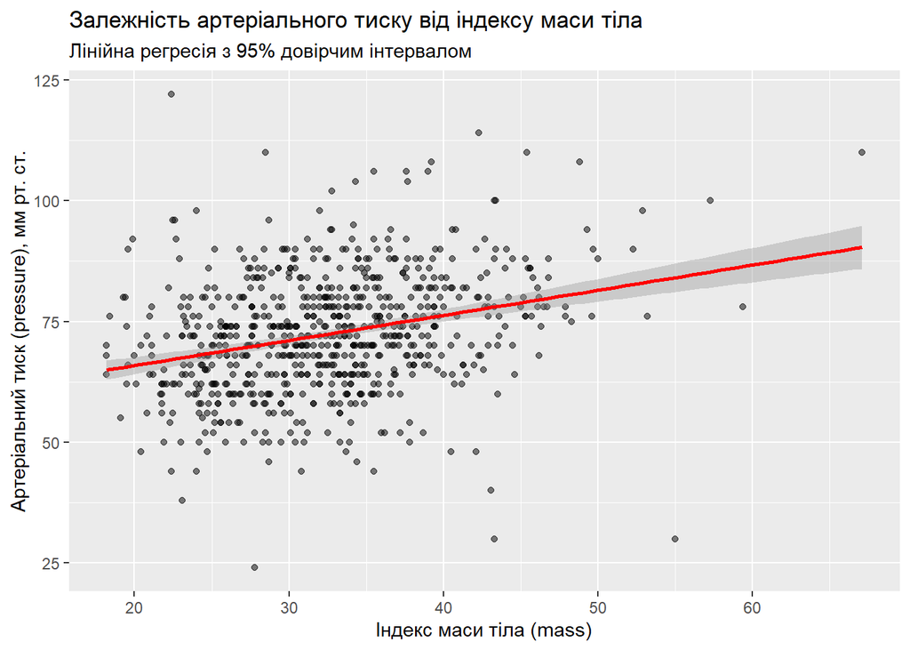

```r
ggplot(diabetes_clean, aes(x = mass, y = pressure)) +
  geom_point(alpha = 0.5) +
  stat_smooth(method = "lm", col = "red") +
  labs(title = "Залежність артеріального тиску від індексу маси тіла",
       subtitle = "Лінійна регресія з 95% довірчим інтервалом",
       x = "Індекс маси тіла (mass)",
       y = "Артеріальний тиск (pressure), мм рт. ст.")
```

Графік підтверджує наявність слабкої позитивної тенденції. Більшість точок згрупована, але є викиди, які можуть впливати на модель.

- Побудова лінійної регресійної моделі

Тепер побудуємо саму модель за допомогою функції `lm()` і проаналізуємо її результати.

```r
# Побудова моделі
model <- lm(pressure ~ mass, data = diabetes_clean)

# Виведення результатів моделі
summary(model)
```

```
##
## Call:
## lm(formula = pressure ~ mass, data = diabetes_clean)
##
## Residuals:
##     Min      1Q  Median      3Q     Max
## -54.081  -7.628  -0.331   7.262  54.868
##
## Coefficients:
##             Estimate Std. Error t value Pr(>|t|)
## (Intercept) 55.48694    2.11810  26.197  < 2e-16 ***
## mass         0.51989    0.06382   8.147 1.63e-15 ***
## ---
## Signif. codes:  0 '***' 0.001 '**' 0.01 '*' 0.05 '.' 0.1 ' ' 1
##
## Residual standard error: 11.86 on 727 degrees of freedom
## Multiple R-squared:  0.08365,    Adjusted R-squared:  0.08239
## F-statistic: 66.37 on 1 and 727 DF,  p-value: 1.63e-15
```

**Прогноз на основі моделі**

Ми можемо використовувати побудовану модель для прогнозування. Наприклад, розрахуємо очікуваний артеріальний тиск для пацієнток з ІМТ 25, 30 та 35, а також 95% довірчий інтервал для цих прогнозів.

```r
# Створюємо датафрейм з новими даними для прогнозу
new_data <- data.frame(mass = c(25, 30, 35))

# Робимо прогноз
predict(model, newdata = new_data, interval = "confidence")
```

```
##        fit      lwr      upr
## 1 68.48410 67.21173 69.75646
## 2 71.08353 70.16766 71.99940
## 3 73.68296 72.76452 74.60140
```

```r
# Створюємо датафрейм з новими значеннями ІМТ для прогнозу
new_data <- data.frame(mass = c(25, 30, 35))

# Прогнозування середнього значення та 95% довірчого інтервалу
predictions <- predict(model, newdata = new_data, interval = "confidence")

# Об'єднуємо вхідні дані та прогнози в один датафрейм
results_df <- cbind(new_data, predictions)

# Встановлюємо бібліотеку knitr, якщо її ще немає
# install.packages("knitr")
library(knitr)

# Виводимо результати у вигляді гарної таблиці за допомогою kable()
kable(
  results_df,
  caption = "Таблиця 2. Точковий та інтервальний прогноз артеріального тиску",
  col.names = c("Індекс маси тіла (mass)", "Прогнозований тиск (fit)", "Нижня межа 95% (lwr)", "Верхня межа 95% (upr)"),
  digits = 2
)
```

Таблиця 2. Точковий та інтервальний прогноз артеріального тиску

| Індекс маси тіла (mass) | Прогнозований тиск (fit) | Нижня межа 95% (lwr) | Верхня межа 95% (upr) |
| --- | --- | --- | --- |
| 25 | 68.48 | 67.21 | 69.76 |
| 30 | 71.08 | 70.17 | 72.00 |
| 35 | 73.68 | 72.76 | 74.60 |

Наприклад, для пацієнтки з ІМТ 30 модель прогнозує середній артеріальний тиск 71.08 мм рт. ст. з 95% впевненістю, що справжнє середнє значення знаходиться в межах від 70.17 до 72.00 мм рт. ст.

## References

1. James, G., Witten, D., Hastie, T., & Tibshirani, R. (2023). *An Introduction to Statistical Learning: with Applications in R (3rd ed.)*. Springer.
2. Wickham, H., & Grolemund, G. (2017). *R for Data Science: Import, Tidy, Transform, Visualize, and Model Data*. O’Reilly Media.
3. Kuhn, M., & Silge, J. (2022). *Tidy Modeling with R*. O’Reilly Media.
4. Han, J., Pei, J., & Kamber, M. (2022). *Data Mining: Concepts and Techniques (4th ed.)*. Morgan Kaufmann.